# Greenhouse Plant Analyses

2026-10-06

```r
library(tidyverse)
library(kableExtra)
library(readr)
library(misty)
library(stringr)
library(BSDA)
library(car)
library(ggpubr)
library(RColorBrewer)
library(pillar)
library(readxl)
library(gridExtra)
library(rstatix)
library(effectsize)
library(npmv)
```

| [Welcome](https://jmhulbert.github.io/swordfern) | [Data](https://jmhulbert.github.io/swordfern/data) | [Methods](https://jmhulbert.github.io/swordfern/methods) | [Analyses](https://jmhulbert.github.io/swordfern/analyses) | [Discussion](https://jmhulbert.github.io/swordfern/discussion) | [Maps](https://jmhulbert.github.io/swordfern/maps) |
| --- | --- | --- | --- | --- | --- |

| oomycete | illumina | [greenhouse-plants](https://jmhulbert.github.io/swordfern/plants) | [iNaturalist](https://jmhulbert.github.io/swordfern/analyses/inaturalist/) |
| --- | --- | --- | --- |

# Greenhouse data

```r
greenhouse.data <- read.csv("https://github.com/jmhulbert/swordfern/raw/refs/heads/main/data/greenhouse/Final-Greenhouse-Data-Combined.csv")
greenhouse.data <- rename(greenhouse.data, "Weight" = "Weight..g.")
greenhouse.data$Total.Fronds <- greenhouse.data$Healthy.Fronds + greenhouse.data$Crispy.Fronds
```

```r
greenhouse.data <- greenhouse.data %>% mutate(Proportion.Crispy.Fronds = Crispy.Fronds/Total.Fronds)
```

## Seward Soil Trials

```r
seward.data <- greenhouse.data %>% filter(Experiment == "Seward Soil")
```

### Data Visualization

Visualize data for Seward soil trials by comparing weights and number of fronds (total, healthy, and unhealthy) between treatment groups (control - potting mix, sterilized, wild).

#### Frond Health

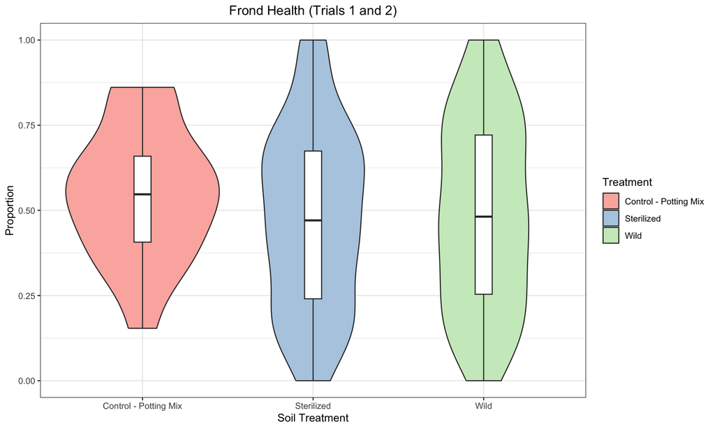

```r
ggplot(seward.data, aes(x = Treatment, y = Proportion.Crispy.Fronds, fill = Treatment)) +
  geom_violin() +
  geom_boxplot(width = 0.1, fill = "white") +
  labs(title = "Frond Health (Trials 1 and 2)", y = "Proportion", x = "Soil Treatment") +
  theme_bw() +
  theme(plot.title = element_text(hjust = 0.5))+
  scale_fill_brewer(palette = "Pastel1")
```

#### Root Mass

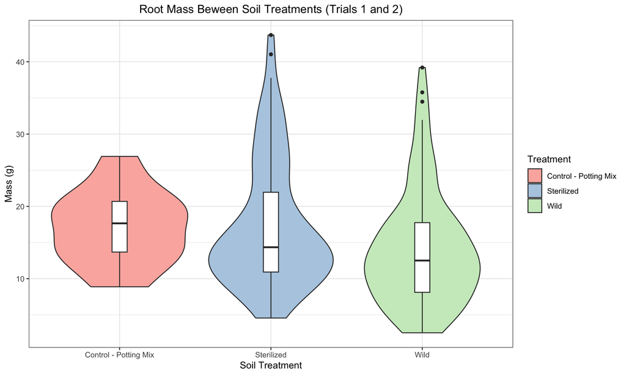

```r
ggplot(seward.data, aes(x = Treatment, y = Weight, fill = Treatment)) +
  geom_violin() +
  geom_boxplot(width = 0.1, fill = "white") +
  labs(title = "Root Mass Beween Soil Treatments (Trials 1 and 2)", y = "Mass (g)", x = "Soil Treatment") +
    scale_fill_brewer(palette = "Pastel1") +
  theme_bw() +
  theme(plot.title =  element_text(hjust = 0.5))
```

### Analyses

#### Check equality of variances

##### Frond Health

```r
leveneTest(Proportion.Crispy.Fronds~as.factor(Treatment), data=seward.data, na.rm = TRUE)
```

```
## Levene's Test for Homogeneity of Variance (center = median: TRUE)
##        Df F value  Pr(>F)
## group   2  2.3775 0.09557 .
##       188
## ---
## Signif. codes:  0 '***' 0.001 '**' 0.01 '*' 0.05 '.' 0.1 ' ' 1
```

There is no evidence for a difference in variability (spread) of crispy fond proportions between groups,, thus satisfying equal variance assumption of anova

##### Root Mass

```r
leveneTest(Weight~as.factor(Treatment), data=seward.data, na.rm = TRUE)
```

```
## Levene's Test for Homogeneity of Variance (center = median: TRUE)
##        Df F value Pr(>F)
## group   2  1.3562 0.2601
##       189
```

There is no evidence for a difference in variability (spread) of root mass between groups, thus satisfying equal variance assumption of anova

#### Check for differences in means

##### Frond Health

```r
anova.seward <- oneway.test(Proportion.Crispy.Fronds ~ Treatment, data = seward.data, var.equal = TRUE)
anova.seward
```

```
##
##  One-way analysis of means
##
## data:  Proportion.Crispy.Fronds and Treatment
## F = 0.55596, num df = 2, denom df = 188, p-value = 0.5745
```

```r
seward.aov <- aov(Proportion.Crispy.Fronds~Treatment, data = seward.data)
summary(seward.aov)
```

```
##              Df Sum Sq Mean Sq F value Pr(>F)
## Treatment     2  0.077 0.03864   0.556  0.574
## Residuals   188 13.067 0.06950
## 1 observation deleted due to missingness
```

```r
TukeyHSD(seward.aov, conf.level = .95)
```

```
##   Tukey multiple comparisons of means
##     95% family-wise confidence level
##
## Fit: aov(formula = Proportion.Crispy.Fronds ~ Treatment, data = seward.data)
##
## $Treatment
##                                         diff         lwr        upr     p adj
## Sterilized-Control - Potting Mix -0.07196438 -0.23323600 0.08930725 0.5437344
## Wild-Control - Potting Mix       -0.05868393 -0.22011621 0.10274835 0.6669033
## Wild-Sterilized                   0.01328045 -0.08142465 0.10798556 0.9413188
```

There was no evidence for a difference in mean proportion crispy fronds between treatments

##### Root Mass

```r
anova.seward <- oneway.test(Weight ~ Treatment, data = seward.data, var.equal = TRUE)
anova.seward
```

```
##
##  One-way analysis of means
##
## data:  Weight and Treatment
## F = 3.4836, num df = 2, denom df = 189, p-value = 0.03268
```

```r
seward.aov <- aov(Weight~Treatment, data = seward.data)
summary(seward.aov)
```

```
##              Df Sum Sq Mean Sq F value Pr(>F)
## Treatment     2    463  231.37   3.484 0.0327 *
## Residuals   189  12553   66.42
## ---
## Signif. codes:  0 '***' 0.001 '**' 0.01 '*' 0.05 '.' 0.1 ' ' 1
```

```r
TukeyHSD(seward.aov, conf.level = .95)
```

```
##   Tukey multiple comparisons of means
##     95% family-wise confidence level
##
## Fit: aov(formula = Weight ~ Treatment, data = seward.data)
##
## $Treatment
##                                        diff       lwr        upr     p adj
## Sterilized-Control - Potting Mix  0.2368774 -4.748279  5.2220335 0.9930778
## Wild-Control - Potting Mix       -2.9195594 -7.904715  2.0655967 0.3515813
## Wild-Sterilized                  -3.1564368 -6.075445 -0.2374283 0.0305590
```

There was evidence for an effect of treatment on root mass, F(2, 189) = 3.48, p = .033. Tukey’s post hoc comparisons indicated that mean weight was lower in the Wild treatment than in the Sterilized treatment (mean difference = −3.16g, 95% CI [−6.08g, −0.24g], adjusted p = .031). Neither treatment differed significantly from the Control–Potting Mix group.

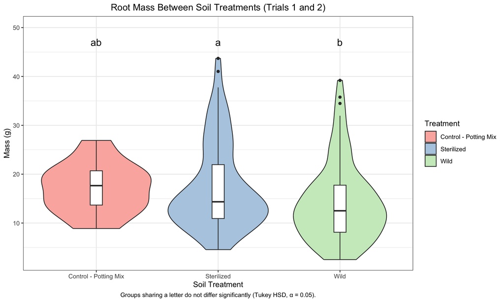

```r
# Letters based on your Tukey results
letters_df <- data.frame(
  Treatment = c("Sterilized", "Control - Potting Mix", "Wild"),
  letter = c("a", "ab", "b")
)

# Position letters above the highest observation
weight_range <- range(seward.data$Weight, na.rm = TRUE)
letters_df$y <- weight_range[2] + 0.08 * diff(weight_range)

ggplot(seward.data, aes(x = Treatment, y = Weight, fill = Treatment)) +
  geom_violin() +
  geom_boxplot(width = 0.1, fill = "white") +
  geom_text(
    data = letters_df,
    aes(x = Treatment, y = y, label = letter),
    inherit.aes = FALSE,
    size = 5
  ) +
  labs(
    title = "Root Mass Between Soil Treatments (Trials 1 and 2)",
    y = "Mass (g)",
    x = "Soil Treatment",
    caption = "Groups sharing a letter do not differ significantly (Tukey HSD, α = 0.05)."
  ) +
  scale_fill_brewer(palette = "Pastel1") +
  scale_y_continuous(expand = expansion(mult = c(0.05, 0.12))) +
  theme_bw() +
  theme(plot.title = element_text(hjust = 0.5),
        plot.caption = element_text(hjust = 0.5)
  )
```

## Inoculation Trials

```r
greenhouse.data <- greenhouse.data %>%
  mutate(Experiment = case_when(
    str_detect(`Trial.x`, "Inoculation") ~ "Inoculation",
    str_detect(`Trial.x`, "Seward") ~ "Seward Soil",
    TRUE ~ NA
  ))

greenhouse.data <- greenhouse.data %>%
  mutate(Treatment = case_when(
    str_detect(`Fern.Number`, "W[[:digit:]]") ~ "Wild",
    str_detect(`Fern.Number`, "NONE") ~ "Control",
    str_detect(`Fern.Number`, "BLA") ~ "Control",
    str_detect(`Fern.Number`, "OCC") ~ "Phytophthora occultans",
    str_detect(`Fern.Number`, "OBS") ~ "Phytophthora obscura",
    str_detect(`Fern.Number`, "SYR") ~ "Phytophthora syringae",
    str_detect(`Fern.Number`, "CAM") ~ "Phytophthora cambivora",
    str_detect(`Fern.Number`, "CAC") ~ "Phytophthora cactorum",
    str_detect(`Fern.Number`, "EUR") ~ "Phytophthora clade 7 sp. 1",
    str_detect(`Fern.Number`, "PLU") ~ "Phytophthora plurivora",
    str_detect(`Fern.Number`, "FLE") ~ "Phytophthora clade 7 sp. 1",
    str_detect(`Fern.Number`, "GIN") ~ "Globosporangium intermedium",
    str_detect(`Fern.Number`, "C[[:digit:]]") ~ "Sterilized",
    str_detect(`Fern.Number`, "P[[:digit:]]") ~ "Control - Potting Mix",
    TRUE ~ NA
  ))

greenhouse.data <- greenhouse.data %>%
  mutate(Weight = replace_when(Weight,
    Fern.Number == "EURA062" ~ 5.3,
    Fern.Number == "EURA063" ~ 9.9,
    Fern.Number == "EURA064" ~ 2.72,
    Fern.Number == "SYRB013" ~ 4.15,
    Fern.Number == "SYRB014" ~ 5.39,
    Fern.Number == "SYRB015" ~ 4.56,
    Fern.Number == "SYRB016" ~ 5.75,
    Fern.Number == "SYRB017" ~ 14.75,
    Fern.Number == "SYRB018" ~ 8.76
      )
  )

inoc.data <- greenhouse.data %>% filter(Experiment == "Inoculation")
inoc1 <- inoc.data %>% filter(Trial.x == "Inoculation Trial One")
```

#### Visualize Data

##### Both Trials

###### Frond Health

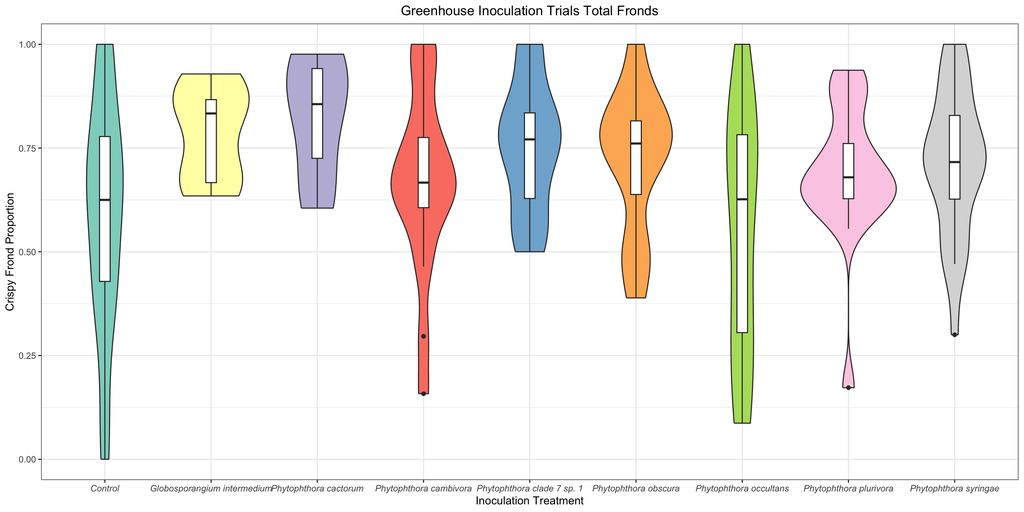

```r
ggplot(inoc.data, aes(x = Treatment, y = Proportion.Crispy.Fronds, fill = Treatment)) +
  geom_violin() +
  geom_boxplot(width=0.1, fill = "white") +
  labs(title = "Greenhouse Inoculation Trials Total Fronds", y = "Crispy Frond Proportion", x= "Inoculation Treatment") +
  theme_bw()+
  theme(plot.title = element_text(hjust = 0.5),
        legend.position = "bottom",
        axis.text.x = element_text(face = "italic"),
        legend.text = element_text(face = "italic")
        ) +
  scale_fill_brewer(palette = "Set3")+
  guides(fill="none")
```

##### Inoculation Trial 1

###### Frond Health

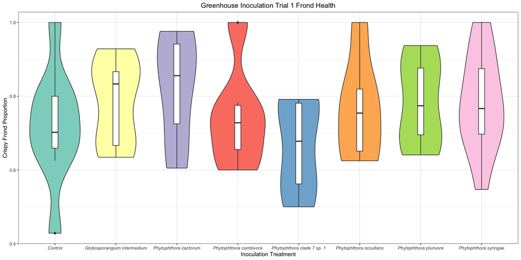

```r
ggplot(inoc1, aes(x = Treatment, y = Proportion.Crispy.Fronds, fill = Treatment)) +
  geom_violin() +
  geom_boxplot(width=0.1, fill = "white") +
  labs(title = "Greenhouse Inoculation Trial 1 Frond Health", y = "Crispy Frond Proportion", x= "Inoculation Treatment") +
  theme_bw()+
  theme(plot.title = element_text(hjust = 0.5),
        legend.position = "bottom",
        axis.text.x = element_text(face = "italic"),
        legend.text = element_text(face = "italic")
        ) +
  scale_fill_brewer(palette = "Set3")+
  guides(fill="none")
```

###### Root Mass

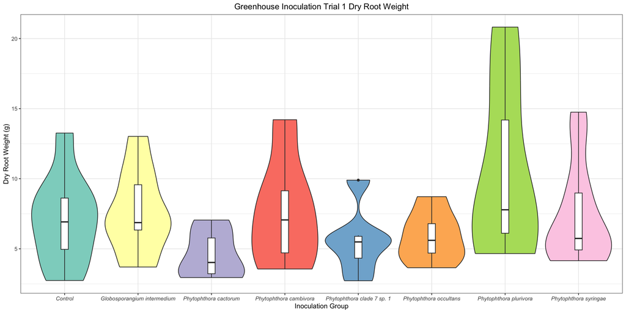

```r
ggplot(inoc1, aes(x = Treatment, y = Weight, fill = Treatment)) +
  geom_violin(scale = "width") +
  geom_boxplot(width=0.1, fill = "white") +
  labs(title = "Greenhouse Inoculation Trial 1 Dry Root Weight", y = "Dry Root Weight (g)", x= "Inoculation Group") +
  theme_bw() +
  theme(plot.title = element_text(hjust = 0.5),
        legend.position = "bottom",
        axis.text.x = element_text(face = "italic"),
        legend.text = element_text(face = "italic")
        ) +
  scale_fill_brewer(palette = "Set3") +
  guides(fill="none")
```

#### Analyses

##### Check data for equality of variances

```r
leveneTest(Proportion.Crispy.Fronds ~ as.factor(Treatment), data = inoc1, na.rm = TRUE)
```

```
## Levene's Test for Homogeneity of Variance (center = median: TRUE)
##       Df F value Pr(>F)
## group  7  0.0495 0.9998
##       52
```

```r
leveneTest(Weight ~ as.factor(Treatment), data = inoc1, na.rm = TRUE)
```

```
## Levene's Test for Homogeneity of Variance (center = median: TRUE)
##       Df F value Pr(>F)
## group  7  1.2205 0.3085
##       52
```

##### ANOVA on inoculation trial 1

```r
anova.inoc1 <- oneway.test(`Weight` ~ Treatment, data = inoc1, var.equal = TRUE)
anova.inoc1
```

```
##
##  One-way analysis of means
##
## data:  Weight and Treatment
## F = 1.5601, num df = 7, denom df = 52, p-value = 0.1683
```

```r
inoc1.aov <- aov(Weight~Treatment, data = inoc1)
summary(inoc1.aov)
```

```
##             Df Sum Sq Mean Sq F value Pr(>F)
## Treatment    7  134.7   19.25    1.56  0.168
## Residuals   52  641.6   12.34
```

##### Cryptogea

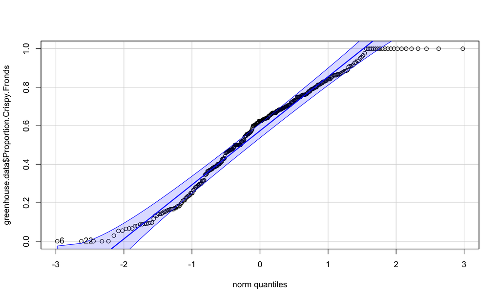

```
## [1]  6 22
```

```r
greenhouse.data$cryptogea <- "No"

greenhouse.data <- greenhouse.data %>%
  mutate(cryptogea = replace_when(cryptogea,
    str_detect(`Fern.Number`, "BLAB6") ~ "Yes",
    str_detect(`Fern.Number`, "OCCB2") ~ "Yes",
    str_detect(`Fern.Number`, "EURA5") ~ "Yes",
    str_detect(`Fern.Number`, "SYRA1") ~ "Yes",
    str_detect(`Fern.Number`, "EURB6") ~ "Yes",
    str_detect(`Fern.Number`, "PLUB1") ~ "Yes",
    str_detect(`Fern.Number`, "PLUA4") ~ "Yes",
    str_detect(`Fern.Number`, "EURB5") ~ "Yes",
    str_detect(`Fern.Number`, "W70") ~ "Yes",
    str_detect(`Fern.Number`, "W72") ~ "Yes",
    str_detect(`Fern.Number`, "C72") ~ "Yes",
    str_detect(`Fern.Number`, "C51") ~ "Yes",
    str_detect(`Fern.Number`, "W61") ~ "Yes",
    str_detect(`Fern.Number`, "GINA130") ~ "Yes",
  ))
qqPlot(greenhouse.data$Proportion.Crispy.Fronds)
```

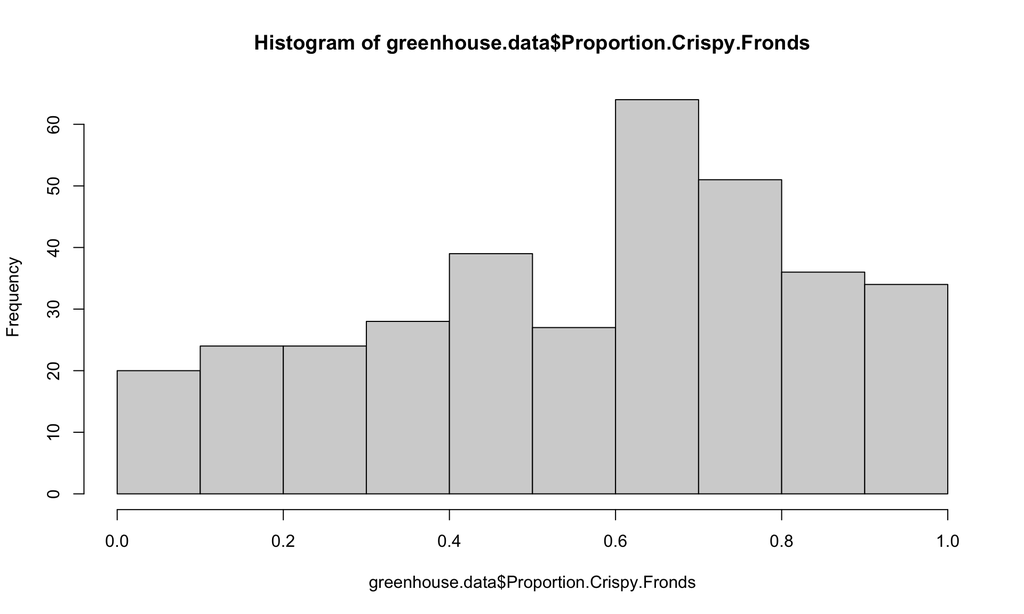

```r
hist(greenhouse.data$Proportion.Crispy.Fronds)
```

```r
greenhouse.data %>% shapiro_test(Proportion.Crispy.Fronds)
```

```
## # A tibble: 1 × 3
##   variable                 statistic           p
##   <chr>                        <dbl>       <dbl>
## 1 Proportion.Crispy.Fronds     0.965 0.000000218
```

Enough evidence to reject normality from visual inspection of QQ plot and histogram as well as a significant result from the Shapiro-Wilk test.

```r
wilcox.test(Proportion.Crispy.Fronds~ cryptogea, data=greenhouse.data)
```

```
##
##  Wilcoxon rank sum test with continuity correction
##
## data:  Proportion.Crispy.Fronds by cryptogea
## W = 1273.5, p-value = 0.004039
## alternative hypothesis: true location shift is not equal to 0
```

##### Reioslated ferns

```r
greenhouse.data$reisolated <- "No"

greenhouse.data <- greenhouse.data %>%
  mutate(reisolated = replace_when(reisolated,
    str_detect(`Fern.Number`, "BLAB6") ~ "P. cryptogea like",
    str_detect(`Fern.Number`, "OCCB2") ~ "P. cryptogea like",
    str_detect(`Fern.Number`, "EURA5") ~ "P. cryptogea like",
    str_detect(`Fern.Number`, "SYRA1") ~ "P. cryptogea like",
    str_detect(`Fern.Number`, "EURB6") ~ "P. cryptogea like",
    str_detect(`Fern.Number`, "PLUB1") ~ "P. cryptogea like",
    str_detect(`Fern.Number`, "PLUA4") ~ "P. cryptogea like",
    str_detect(`Fern.Number`, "EURB5") ~ "P. cryptogea like",
    str_detect(`Fern.Number`, "W70") ~ "P. cryptogea like",
    str_detect(`Fern.Number`, "W72") ~ "P. cryptogea like",
    str_detect(`Fern.Number`, "C72") ~ "P. cryptogea like",
    str_detect(`Fern.Number`, "C51") ~ "P. cryptogea like",
    str_detect(`Fern.Number`, "W61") ~ "P. cryptogea like",
    str_detect(`Fern.Number`, "GINA130") ~ "P. cryptogea like",
    str_detect(`Fern.Number`, "OCCB6") ~ "P. occultans",
    str_detect(`Fern.Number`, "OCCB5") ~ "P. occultans",
    str_detect(`Fern.Number`, "OCCB4") ~ "P. occultans",
    str_detect(`Fern.Number`, "EURA5") ~ "P. occultans",
    str_detect(`Fern.Number`, "OCCA4") ~ "P. occultans",
    str_detect(`Fern.Number`, "OCCA2") ~ "P. occultans",
    str_detect(`Fern.Number`, "OCCB1") ~ "P. occultans",
    str_detect(`Fern.Number`, "OCCB3") ~ "P. occultans",
    str_detect(`Fern.Number`, "PLUB2") ~ "P. plurivora",
    str_detect(`Fern.Number`, "EURA5") ~ "P. sansomeana",
    str_detect(`Fern.Number`, "SYRB4") ~ "P. clade 7 sp. 1",
    str_detect(`Fern.Number`, "CACA83") ~ "P. alpina",
    str_detect(`Fern.Number`, "PLUA27") ~ "P. plurivora",
    str_detect(`Fern.Number`, "PLUA25") ~ "P. plurivora",
    str_detect(`Fern.Number`, "CAMA45") ~ "P. cambivora",
  ))
```

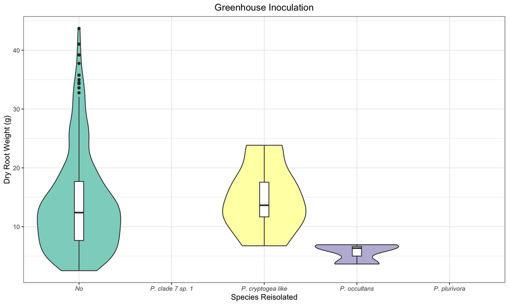

```r
ggplot(greenhouse.data, aes(x = reisolated, y = Weight, fill = reisolated)) +
  geom_violin(scale = "width") +
  geom_boxplot(width=0.1, fill = "white") +
  labs(title = "Greenhouse Inoculation", y = "Dry Root Weight (g)", x= "Species Reisolated") +
  theme_bw() +
  theme(plot.title = element_text(hjust = 0.5),
        legend.position = "bottom",
        axis.text.x = element_text(face = "italic"),
        legend.text = element_text(face = "italic")
        ) +
  scale_fill_brewer(palette = "Set3") +
  guides(fill="none")
```